# R Notebook

# February 2020

# HBC single-cell RNA-seq workshop

# Single-cell RNA-seq analysis - QC

```r
library(SingleCellExperiment)
library(Seurat)
library(tidyverse)
library(Matrix)
library(scales)
library(cowplot)
library(RCurl)
```

# We use Read10X to read the data, just give the folder directory. This function is from the Seurat package and will use the Cell Ranger output directory as input. In this way individual files do not need to be loaded in, instead the function will load and combine them into a sparse matrix for you.

```r
# How to read in 10X data for a single sample (output is a sparse matrix)
ctrl_counts <- Read10X(data.dir = "data/ctrl_raw_feature_bc_matrix")

# Turn count matrix into a Seurat object (output is a Seurat object)
ctrl <- CreateSeuratObject(counts = ctrl_counts,
                           min.features = 100)
```

```r
# Explore the metadata
head(ctrl@meta.data)
```

|  | orig.ident | nCount_RNA | nFeature_RNA |
| --- | --- | --- | --- |
| AAACATACAATGCC-1 | SeuratProject | 2344 | 874 |
| AAACATACATTTCC-1 | SeuratProject | 3125 | 896 |
| AAACATACCAGAAA-1 | SeuratProject | 2578 | 725 |
| AAACATACCAGCTA-1 | SeuratProject | 3261 | 979 |
| AAACATACCATGCA-1 | SeuratProject | 746 | 362 |
| AAACATACCTCGCT-1 | SeuratProject | 3519 | 866 |

# We have multiple data input directories, use for loop to read them all and combine them as one dataset

```r
# Create each individual Seurat object for every sample
for (file in c("ctrl_raw_feature_bc_matrix", "stim_raw_feature_bc_matrix")){
        seurat_data <- Read10X(data.dir = paste0("data/", file))
        seurat_obj <- CreateSeuratObject(counts = seurat_data,
                                         min.features = 100,
                                         project = file)
        assign(file, seurat_obj)
}
```

```r
# Check the metadata in the new Seurat objects
head(ctrl_raw_feature_bc_matrix@meta.data)
```

|  | orig.ident | nCount_RNA | nFeature_RNA |
| --- | --- | --- | --- |
| AAACATACAATGCC-1 | ctrl_raw_feature_bc_matrix | 2344 | 874 |
| AAACATACATTTCC-1 | ctrl_raw_feature_bc_matrix | 3125 | 896 |
| AAACATACCAGAAA-1 | ctrl_raw_feature_bc_matrix | 2578 | 725 |
| AAACATACCAGCTA-1 | ctrl_raw_feature_bc_matrix | 3261 | 979 |
| AAACATACCATGCA-1 | ctrl_raw_feature_bc_matrix | 746 | 362 |
| AAACATACCTCGCT-1 | ctrl_raw_feature_bc_matrix | 3519 | 866 |

```r
head(stim_raw_feature_bc_matrix@meta.data)
```

|  | orig.ident | nCount_RNA | nFeature_RNA |
| --- | --- | --- | --- |
| AAACATACCAAGCT-1 | stim_raw_feature_bc_matrix | 1221 | 606 |
| AAACATACCCCTAC-1 | stim_raw_feature_bc_matrix | 1782 | 807 |
| AAACATACCCGTAA-1 | stim_raw_feature_bc_matrix | 1451 | 605 |
| AAACATACCCTCGT-1 | stim_raw_feature_bc_matrix | 1549 | 747 |
| AAACATACGAGGTG-1 | stim_raw_feature_bc_matrix | 1303 | 558 |
| AAACATACGCGAAG-1 | stim_raw_feature_bc_matrix | 5445 | 1330 |

```r
# Create a merged Seurat object
merged_seurat <- merge(x = ctrl_raw_feature_bc_matrix,
                       y = stim_raw_feature_bc_matrix,
                       add.cell.id = c("ctrl", "stim"))
```

```r
# Check that the merged object has the appropriate sample-specific prefixes
head(merged_seurat@meta.data)
```

|  | orig.ident | nCount_RNA | nFeature_RNA |
| --- | --- | --- | --- |
| ctrl_AAACATACAATGCC-1 | ctrl_raw_feature_bc_matrix | 2344 | 874 |
| ctrl_AAACATACATTTCC-1 | ctrl_raw_feature_bc_matrix | 3125 | 896 |
| ctrl_AAACATACCAGAAA-1 | ctrl_raw_feature_bc_matrix | 2578 | 725 |
| ctrl_AAACATACCAGCTA-1 | ctrl_raw_feature_bc_matrix | 3261 | 979 |
| ctrl_AAACATACCATGCA-1 | ctrl_raw_feature_bc_matrix | 746 | 362 |
| ctrl_AAACATACCTCGCT-1 | ctrl_raw_feature_bc_matrix | 3519 | 866 |

```r
tail(merged_seurat@meta.data)
```

|  | orig.ident | nCount_RNA | nFeature_RNA |
| --- | --- | --- | --- |
| stim_TTTGCATGCGACAT-1 | stim_raw_feature_bc_matrix | 620 | 295 |
| stim_TTTGCATGCTAAGC-1 | stim_raw_feature_bc_matrix | 1641 | 545 |
| stim_TTTGCATGGGACGA-1 | stim_raw_feature_bc_matrix | 1233 | 518 |
| stim_TTTGCATGGTGAGG-1 | stim_raw_feature_bc_matrix | 1084 | 469 |
| stim_TTTGCATGGTTTGG-1 | stim_raw_feature_bc_matrix | 818 | 432 |
| stim_TTTGCATGTCTTAC-1 | stim_raw_feature_bc_matrix | 1104 | 438 |

## The added columns include:

- orig.ident: this often contains the sample identity if known, but will default to project as we had assigned it
- nCount_RNA: number of UMIs per cell
- nFeature_RNA: number of genes detected per cell ## We need to calculate some additional metrics for plotting:
- number of genes detected per UMI: this metric with give us an idea of the complexity of our dataset (more genes detected per UMI, more complex our data)
- mitochondrial ratio: this metric will give us a percentage of cell reads originating from the mitochondrial genes

The number of genes per UMI for each cell is quite easy to calculate, and we will log10 transform the result for better comparison between samples.

```r
# Add number of genes per UMI for each cell to metadata
merged_seurat$log10GenesPerUMI <- log10(merged_seurat$nFeature_RNA) / log10(merged_seurat$nCount_RNA)
```

Seurat has a convenient function that allows us to calculate the proportion of transcripts mapping to mitochondrial genes. The PercentageFeatureSet() will take a pattern and search the gene identifiers. For each column (cell) it will take the sum of the counts slot for features belonging to the set, divide by the column sum for all features and multiply by 100. Since we want the ratio value for plotting, we will reverse that step by then dividing by 100.

```r
# Compute percent mito ratio
merged_seurat$mitoRatio <- PercentageFeatureSet(object = merged_seurat, pattern = "^MT-")
merged_seurat$mitoRatio <- merged_seurat@meta.data$mitoRatio / 100
```

#NOTE: The pattern provided (“^MT-”) works for human gene names. You may need to adjust depending on your organism of interest. If you weren’t using gene names as the gene ID, then this function wouldn’t work. We have code available to compute this metric on your own.

We need to add additional information to our metadata for our QC metrics, such as the cell IDs, condition information, and various metrics. While it is quite easy to add information directly to the metadata slot in the Seurat object using the $ operator, we will extract the dataframe into a separate variable instead. In this way we can continue to insert additional metrics that we need for our QC analysis without the risk of affecting our merged_seurat object.

We will create the metadata dataframe by extracting the meta.data slot from the Seurat object:

```r
# Create metadata dataframe
metadata <- merged_seurat@meta.data
```

```r
# Add cell IDs to metadata
metadata$cells <- rownames(metadata)

# Rename columns
metadata <- metadata %>%
        dplyr::rename(seq_folder = orig.ident,
                      nUMI = nCount_RNA,
                      nGene = nFeature_RNA)
```

```r
# Create sample column
metadata$sample <- NA
metadata$sample[which(str_detect(metadata$cells, "^ctrl_"))] <- "ctrl"
metadata$sample[which(str_detect(metadata$cells, "^stim_"))] <- "stim"
```

Before we assess our metrics we are going to save all of the work we have done thus far back into our Seurat object. We can do this by simply assigning the dataframe into the meta.data slot:

```r
# Add metadata back to Seurat object
merged_seurat@meta.data <- metadata

# Create .RData object to load at any time
save(merged_seurat, file="data/merged_filtered_seurat.RData")
```

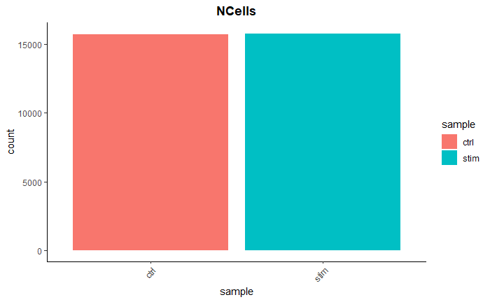

```r
# Visualize the number of cell counts per sample
metadata %>%
    ggplot(aes(x=sample, fill=sample)) +
    geom_bar() +
    theme_classic() +
    theme(axis.text.x = element_text(angle = 45, vjust = 1, hjust=1)) +
    theme(plot.title = element_text(hjust=0.5, face="bold")) +
    ggtitle("NCells")
```

## UMI counts (transcripts) per cell

The UMI counts per cell should generally be above 500, that is the low end of what we expect. If UMI counts are between 500-1000 counts, it is usable but the cells probably should have been sequenced more deeply.

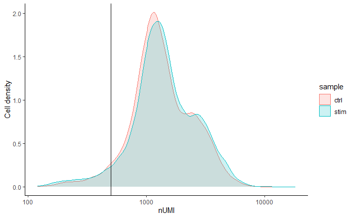

```r
# Visualize the number UMIs/transcripts per cell
metadata %>%
    ggplot(aes(color=sample, x=nUMI, fill= sample)) +
    geom_density(alpha = 0.2) +
    scale_x_log10() +
    theme_classic() +
    ylab("Cell density") +
    geom_vline(xintercept = 500)
```

Genes detected per cell

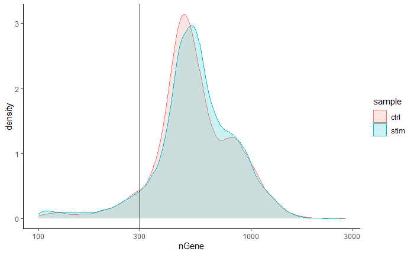

```r
# Visualize the distribution of genes detected per cell via histogram
metadata %>%
    ggplot(aes(color=sample, x=nGene, fill= sample)) +
    geom_density(alpha = 0.2) +
    theme_classic() +
    scale_x_log10() +
    geom_vline(xintercept = 300)
```

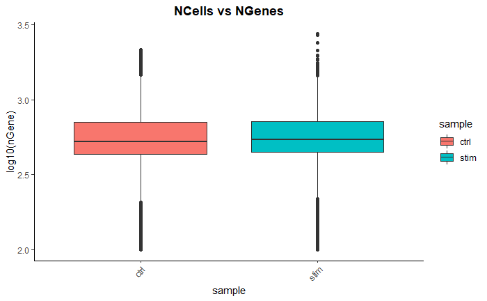

```r
# Visualize the distribution of genes detected per cell via boxplot
metadata %>%
    ggplot(aes(x=sample, y=log10(nGene), fill=sample)) +
    geom_boxplot() +
    theme_classic() +
    theme(axis.text.x = element_text(angle = 45, vjust = 1, hjust=1)) +
    theme(plot.title = element_text(hjust=0.5, face="bold")) +
    ggtitle("NCells vs NGenes")
```

UMIs vs. genes detected

Cells that are poor quality are likely to have low genes and UMIs per cell, and correspond to the data points in the bottom left quadrant of the plot. Good cells will generally exhibit both higher number of genes per cell and higher numbers of UMIs.

With this plot we also evaluate the slope of the line, and any scatter of data points in the bottom right hand quadrant of the plot. These cells have a high number of UMIs but only a few number of genes. These could be dying cells, but also could represent a population of a low complexity celltype (i.e red blood cells).

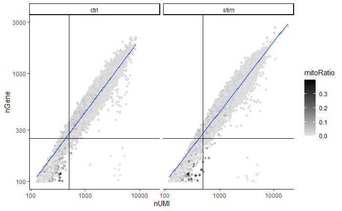

```r
# Visualize the correlation between genes detected and number of UMIs and determine whether strong presence of cells with low numbers of genes/UMIs
metadata %>%
    ggplot(aes(x=nUMI, y=nGene, color=mitoRatio)) +
    geom_point() +
    scale_colour_gradient(low = "gray90", high = "black") +
    stat_smooth(method=lm) +
    scale_x_log10() +
    scale_y_log10() +
    theme_classic() +
    geom_vline(xintercept = 500) +
    geom_hline(yintercept = 250) +
    facet_wrap(~sample)
```

Mitochondrial counts ratio

This metric can identify whether there is a large amount of mitochondrial contamination from dead or dying cells. We define poor quality samples for mitochondrial counts as cells which surpass the 0.2 mitochondrial ratio mark, unless of course you are expecting this in your sample.

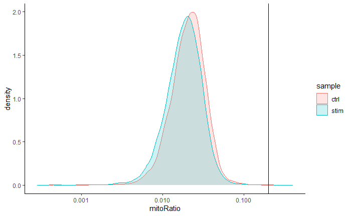

```r
# Visualize the distribution of mitochondrial gene expression detected per cell
metadata %>%
    ggplot(aes(color=sample, x=mitoRatio, fill=sample)) +
    geom_density(alpha = 0.2) +
    scale_x_log10() +
    theme_classic() +
    geom_vline(xintercept = 0.2)
```

Complexity

We can see the samples where we sequenced each cell less have a higher overall complexity, that is because we have not started saturating the sequencing for any given gene for these samples. Outlier cells in these samples might be cells that have a less complex RNA species than other cells. Sometimes we can detect contamination with low complexity cell types like red blood cells via this metric. Generally, we expect the novelty score to be above 0.80.

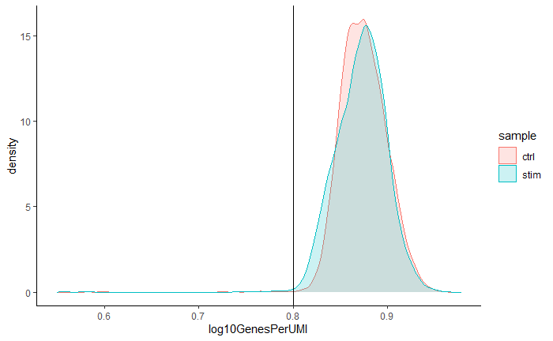

```r
# Visualize the overall complexity of the gene expression by visualizing the genes detected per UMI
metadata %>%
    ggplot(aes(x=log10GenesPerUMI, color = sample, fill=sample)) +
    geom_density(alpha = 0.2) +
    theme_classic() +
    geom_vline(xintercept = 0.8)
```

# Filtering

In conclusion, considering any of these QC metrics in isolation can lead to misinterpretation of cellular signals. For example, cells with a comparatively high fraction of mitochondrial counts may be involved in respiratory processes and may be cells that you would like to keep. Likewise, other metrics can have other biological interpretations. Thus, always consider the joint effects of these metrics when setting thresholds and set them to be as permissive as possible to avoid filtering out viable cell populations unintentionally. Cell-level filtering

Now that we have visualized the various metrics, we can decide on the thresholds to apply which will result in the removal of low quality cells. Often the recommendations mentioned earlier are a rough guideline, and the specific experiment needs to inform the exact thresholds chosen. We will use the following thresholds:

- nUMI > 500
- nGene > 250
- log10GenesPerUMI > 0.8
- mitoRatio < 0.2

To filter, we wil go back to our Seurat object and use the subset() function:

```r
# Filter out low quality reads using selected thresholds - these will change with experiment
filtered_seurat <- subset(x = merged_seurat,
                         subset= (nUMI >= 500) &
                           (nGene >= 250) &
                           (log10GenesPerUMI > 0.80) &
                           (mitoRatio < 0.20))
```

Gene-level filtering

Within our data we will have many genes with zero counts. These genes can dramatically reduce the average expression for a cell and so we will remove them from our data. First we will remove genes that have zero expression in all cells. Additionally, we will perform some filtering by prevalence. If a gene is only expressed in a handful of cells, it is not particularly meaningful as it still brings down the averages for all other cells it is not expressed in. For our data we choose to keep only genes which are expressed in 10 or more cells.

```r
# Output a logical vector for every gene on whether the more than zero counts per cell
# Extract counts
counts <- GetAssayData(object = filtered_seurat, slot = "counts")

# Output a logical vector for every gene on whether the more than zero counts per cell
nonzero <- counts > 0

# Sums all TRUE values and returns TRUE if more than 10 TRUE values per gene
keep_genes <- Matrix::rowSums(nonzero) >= 10

# Only keeping those genes expressed in more than 10 cells
filtered_counts <- counts[keep_genes, ]

# Reassign to filtered Seurat object
filtered_seurat <- CreateSeuratObject(filtered_counts, meta.data = filtered_seurat@meta.data)
```

Saving filtered cells

Based on these QC metrics we would identify any failed samples and move forward with our filtered cells. Often we iterate through the QC metrics using different filtering criteria; it is not necessarily a linear process. When satisfied with the filtering criteria, we would save our filtered cell object for clustering and marker identification.

```r
# Create .RData object to load at any time
save(filtered_seurat, file="data/seurat_filtered.RData")
```